# R shiny App

jiyelee

2020 5 14

## 1. Shiny란?

shiny는 R 패키지 중의 하나로, interactive web applications를 R에서 쉽게 만들 수 있도록 한다.

먼저, 필요한 패키지를 설치한다.

```r
#install.packages("shiny")
library(shiny)
```

### 1.2 Shiny App의 구조

Shiny app은 app.R이라는 하나의 스크립트에 포함되어 있다. 또는, ui.R, server.R로 나누어서 만들 수도 있다.

다음은 app.R의 3가지 구성요소이다.

- user interface
- server function
- call to the shinyApp function

user interface(ui)는 앱의 레이아웃을 만든다. server function에는 앱을 만드는 데 필요한 내용을 담고 있다. shinyApp function은 ui와 server를 묶어 앱 객체를 생성할 수 있도록 한다.

```r
ui <- fluidPage()

server <- function(input,output){

}

shinyApp(ui = ui, server = server)
```

이 코드는 Shiny App을 만드는 데 필요한 최소한의 코드이다. 이 결과는 빈 user interface가 있는 빈 앱을 보여준다.

## 2. user interface(ui) 생성

이제, user interface를 구축하는 방법에 대해서 알아보도록 한다.

### 2.1 레이아웃

Shiny는 fluidPage를 사용하여 사용자의 브라우저 창 크기에 맞게 자동으로 조정되는 디스플레이를 만들 수 있다.이 fluidPage 안에 필요한 요소를 넣어서 user interface를 구성한다. 그리고 fluidPage는 그리드 레이아웃으로 사용할 수 있다. fluidRow()함수로 행을 생성하고, column()함수로 열을 생성한다.

다음의 예시를 통해서 살펴보면, 아래의 ui function은 title panel과 sidebar 레이아웃이 있는 user interface를 생성하고, sidebar panel와 main panel을 포함한다.

```r
ui <- fluidPage(
  titlePanel("title panel"),

  sidebarLayout(
    sidebarPanel("sidebar panel"),
    mainPanel("main panel")
  )
)

server <- function(input,output){

}

shinyApp(ui = ui, server = server)
```

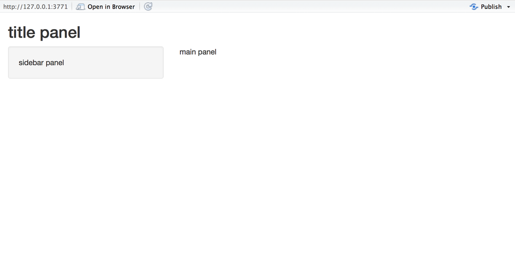

titlePanel과 sidebarLayout은 fluidPage에 가장 많이 활용하는 요소이다. 그리고 sidebarLayout은 항상 2가지 요소가 사용된다.

- sidebarPanel function output
- mainPanel function output

sidebarPanel은 기본적으로 왼쪽으로 나타나지만, 오른쪽으로 옮길 수 있다.

```r
ui <- fluidPage(
  titlePanel("title panel"),

  sidebarLayout(position = "right",
    sidebarPanel("sidebar panel"),
    mainPanel("main panel")
  )
)

server <- function(input,output){

}

shinyApp(ui = ui, server = server)
```

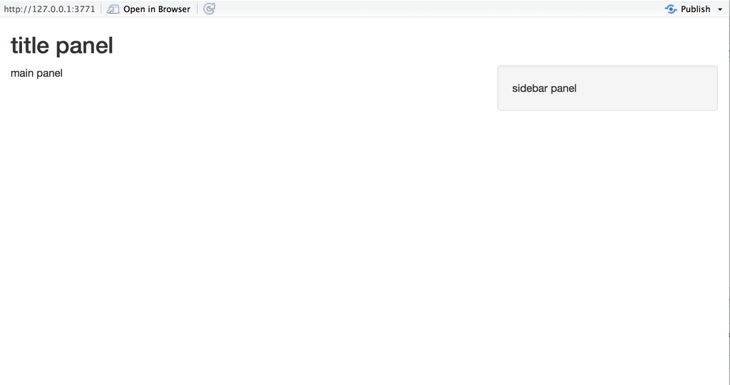

titlePanel과 sidebarLayout을 다양한 형태로 더 많이 만들 수 있다.(https://shiny.rstudio.com/articles/layout-guide.html 참고)

또한, shiny App에 text를 넣을 때 p, h1, h2, h3 등의HTML tag를 활용할 수 있다.tag 종류는 다음과 같다.

```r
names(tags)
```

```
##   [1] "a"           "abbr"        "address"     "area"        "article"
##   [6] "aside"       "audio"       "b"           "base"        "bdi"
##  [11] "bdo"         "blockquote"  "body"        "br"          "button"
##  [16] "canvas"      "caption"     "cite"        "code"        "col"
##  [21] "colgroup"    "command"     "data"        "datalist"    "dd"
##  [26] "del"         "details"     "dfn"         "dialog"      "div"
##  [31] "dl"          "dt"          "em"          "embed"       "eventsource"
##  [36] "fieldset"    "figcaption"  "figure"      "footer"      "form"
##  [41] "h1"          "h2"          "h3"          "h4"          "h5"
##  [46] "h6"          "head"        "header"      "hgroup"      "hr"
##  [51] "html"        "i"           "iframe"      "img"         "input"
##  [56] "ins"         "kbd"         "keygen"      "label"       "legend"
##  [61] "li"          "link"        "main"        "mark"        "map"
##  [66] "menu"        "meta"        "meter"       "nav"         "noscript"
##  [71] "object"      "ol"          "optgroup"    "option"      "output"
##  [76] "p"           "param"       "picture"     "pre"         "progress"
##  [81] "q"           "rp"          "rt"          "ruby"        "s"
##  [86] "samp"        "script"      "section"     "select"      "small"
##  [91] "source"      "span"        "strong"      "style"       "sub"
##  [96] "summary"     "sup"         "table"       "tbody"       "td"
## [101] "template"    "textarea"    "tfoot"       "th"          "thead"
## [106] "time"        "title"       "tr"          "track"       "u"
## [111] "ul"          "var"         "video"       "wbr"
```

### 2.2 Headers

header를 만드는 법은 다음과 같다.

- header function을 선택(e.g., h1 or h5)
- header안에 원하는 text를 넣음

이렇게 하면 해당하는 텍스트가 나타난다. 여러 요소를 쉼표로 구분하면 이어서 배치할 수 있다.

```r
h1("My title")
```

# My title

이제, shiny App에 이를 활용해보도록 하자.

```r
ui <- fluidPage(
  titlePanel("My Shiny App"),
  sidebarLayout(
    sidebarPanel(),
    mainPanel(
      h1("First level title"),
      h2("Second level title"),
      h3("Third level title"),
      h4("Fourth level title"),
      h5("Fifth level title"),
      h6("Sixth level title")
    )
  )
)

server <- function(input,output){

}

shinyApp(ui = ui, server = server)
```

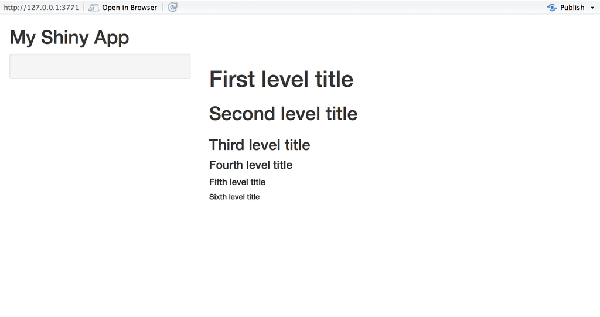

여기서 글씨를 가운데 정렬을 하고 싶다면, option을 활용할 수 있다.

```r
ui <- fluidPage(
  titlePanel("My Shiny App"),
  sidebarLayout(
    sidebarPanel(),
    mainPanel(
      h1("First level title", align = "center"),
      h2("Second level title", align = "center"),
      h3("Third level title", align = "center"),
      h4("Fourth level title", align = "center"),
      h5("Fifth level title", align = "center"),
      h6("Sixth level title", align = "center")
    )
  )
)

server <- function(input,output){

}

shinyApp(ui = ui, server = server)
```

### 2.3 Text style

shiny에서는 텍스트 서식을 변형할 수 있는 다양한 태그 기능을 제공한다. 다음의 예시를 통해서 알아보도록 하자.

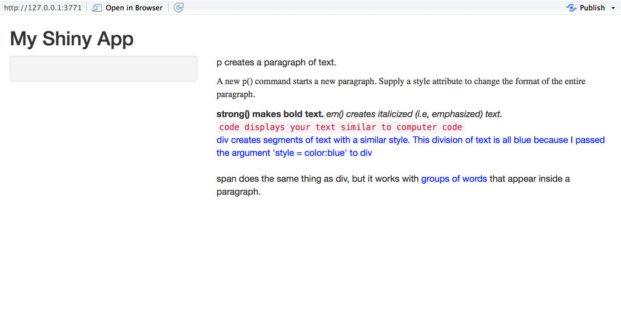

```r
ui <- fluidPage(
  titlePanel("My Shiny App"),
  sidebarLayout(
    sidebarPanel(),
    mainPanel(
      p("p creates a paragraph of text."),
      p("A new p() command starts a new paragraph. Supply a style attribute to change the format of the entire paragraph.", style = "font-family: 'times'; font-si16pt"),
      strong("strong() makes bold text."),
      em("em() creates italicized (i.e, emphasized) text."),
      br(),
      code("code displays your text similar to computer code"),
      div("div creates segments of text with a similar style. This division of text is all blue because I passed the argument 'style = color:blue' to div", style = "color:blue"),
      br(),
      p("span does the same thing as div, but it works with",
        span("groups of words", style = "color:blue"),
        "that appear inside a paragraph.")
    )
  )
)

server <- function(input,output){

}

shinyApp(ui = ui, server = server)
```

### 2.4 Image

shiiny App에 이미지 파일을 넣을 수 있다. 이미지를 넣으려면, 이미지 파일의 이름을 src에 지정하면 되며, 높이와 너비도 변경할 수 있다.(image download: https://shiny.rstudio.com/tutorial/written-tutorial/lesson2/www/rstudio.png)

```r
ui <- fluidPage(
  titlePanel("My Shiny App"),
  sidebarLayout(
    sidebarPanel(),
    mainPanel(
      img(src = "rstudio.png", height = 140, width = 400)
    )
  )
)
server <- function(input,output){

}

shinyApp(ui = ui, server = server)
```

[figure not shown]

### 2.5 widgets

shiny App에는 다양한 widget을 추가할 수 있다. widget은 사용자가 상호작용할 수 있는 웹 요소로, 사용자가 widget을 변경하면 그에 따라 값도 변경되도록 할 수 있다.

먼저, 여러 종류의 widget에 대해서 살펴보자. actionButton, checkboxGroupInput, checkboxInput, dateInput, dateRangeInput 등의 다양한 widget이 있다.

widget을 추가하려면, widget function을 sidebarPanel 또는 mainPanel 등에 배치하면 된다. widget function에 필요한 인수는

- widget 이름: 사용자가 이 이름을 볼 수는 없지만 코드를 작성하면서 widget의 값에 접근할 때 사용하는 이름이다.
- label: widget과 함께 나타나는 부분이다.

```r
actionButton("action", label = "Action")
```

이렇게 작성하는데, “action”이 widget 이름이고, “Action”이 label이다. 다음의 예시를 활용하여 widget에 대해서 자세히 살펴보도록 한다.

```r
ui <- fluidPage(
  titlePanel("Basic widgets"),

  fluidRow(

    column(3,
           h3("Buttons"),
           actionButton("action", "Action"),
           br(),
           br(),
           submitButton("Submit")),

    column(3,
           h3("Single checkbox"),
           checkboxInput("checkbox", "Choice A", value = TRUE)),

    column(3,
           checkboxGroupInput("checkGroup",
                              h3("Checkbox group"),
                              choices = list("Choice 1" = 1,
                                             "Choice 2" = 2,
                                             "Choice 3" = 3),
                              selected = 1)),

    column(3,
           dateInput("date",
                     h3("Date input"),
                     value = "2014-01-01"))
  ),

  fluidRow(

    column(3,
           dateRangeInput("dates", h3("Date range"))),

    column(3,
           fileInput("file", h3("File input"))),

    column(3,
           h3("Help text"),
           helpText("Note: help text isn't a true widget,",
                    "but it provides an easy way to add text to",
                    "accompany other widgets.")),

    column(3,
           numericInput("num",
                        h3("Numeric input"),
                        value = 1))
  ),

  fluidRow(

    column(3,
           radioButtons("radio", h3("Radio buttons"),
                        choices = list("Choice 1" = 1, "Choice 2" = 2,
                                       "Choice 3" = 3),selected = 1)),

    column(3,
           selectInput("select", h3("Select box"),
                       choices = list("Choice 1" = 1, "Choice 2" = 2,
                                      "Choice 3" = 3), selected = 1)),

    column(3,
           sliderInput("slider1", h3("Sliders"),
                       min = 0, max = 100, value = 50),
           sliderInput("slider2", "",
                       min = 0, max = 100, value = c(25, 75))
    ),

    column(3,
           textInput("text", h3("Text input"),
                     value = "Enter text..."))
  )

)

server <- function(input,output){

}

shinyApp(ui = ui, server = server)
```

widget 예시 코드를 살펴보면, fluidPage를 fluidRow()와 column()을 사용하여 레이아웃을 그라인드처럼 사용한 것을 확인할 수 있다. 여기서는 column의 길이를 모두 3으로 동일하게 했지만 길이를 다르게 변경할 수도 있다. 단, 하나의 row 안에서 column의 총합은 최대 12까지 가능하다.

- Buttons: actionButton과 submitButton은 클릭하는 버튼 생성. 버튼을 누르면 앱 화면에 보여주는 결과가 바뀌도록 하는데 활용 가능.
- Checkbox: 값을 지정하는 데 사용할 수 있는 체크박스를 만들어주며 default값 지정 가능. 여러가지 선택지 중에서 선택을 할 수 있으며, 선택한 값에 따라서 다른 결과물을 보여주는 데 활용 가능.
- Date: 날짜값을 지정하는 widget. 날짜 하나를 지정할 수도 있고, 기간 선택도 가능.
- File input: 파일 업로드할 수 있는 widget.
- helpText: 입력 양식에 추가할 수 있는 도움말.
- numericInput: 숫자값을 입력받음.
- radioButtons: 체크박스와 유사하게 값을 선택하는 widget.
- selectInput: select box를 통해서 값을 선택.
- sliderInput: 슬라이드바를 통해서 값을 선택.
- textInput: 텍스트 값을 입력.

## 3. Reactive output

shiny App은 앞서 배운 widget을 활용하여 반응형 결과를 보여줄 수 있다. 먼저, ui에 R 객체를 추가하고, server에서 객체를 만드는 방법에 대해서 코드를 만든다. 객체를 만드는 코드가 widget 값을 호출하면 객체가 반응하게 된다.

먼저, ui에 R 객체를 추가하는데, 다음과 같은 다양한 함수를 제공하고 있다.

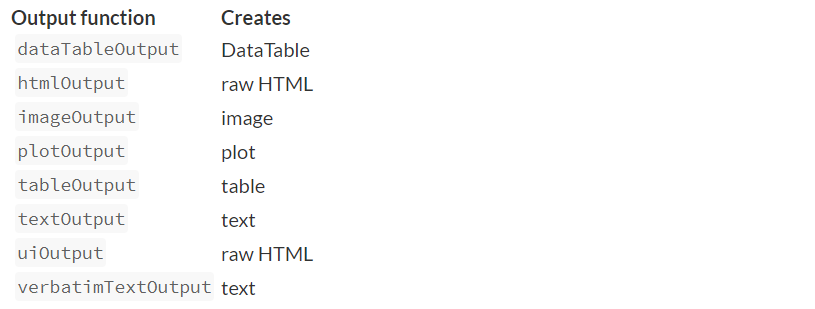

```r
ui <- fluidPage(
  sliderInput("obs", "Number of observations", 0, 1000, 500),
  plotOutput("distPlot")
)
```

여기서 “distplot”은 앞선 widget 이름처럼 plotOutput 이름이다.

그리고 server function에서 해당 객체를 만드는 방법에 대한 코드를 작성한다.ui에서 plotOutput에 해당하는 객체를 만들 때는 renderPlot을, ui에서 Textouput에 해당하는 객체를 만들 때는 renderText를 사용하면 된다.

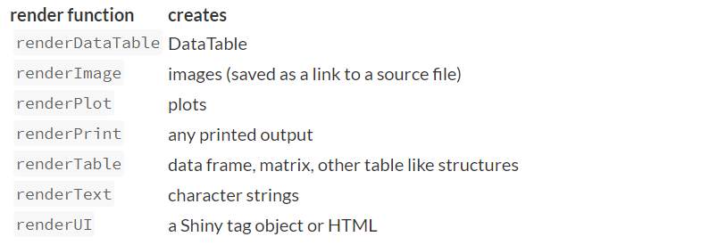

```r
# Define server logic required to draw a histogram
server <- function(input, output) {
  output$distPlot <- renderPlot({
    dist <- rnorm(input$obs)
    hist(dist)
  })
}
```

히토그램을 shiny App에 출력하는데, 이 plotOutput을 sliderInput에 입력되는 값에 따라서 히스토그램의 관측치 수가 바뀌도록 한다. 이처럼, ui에서 input값을 받고, output의 위치를 지정하고, server에서 output을 만드는 과정에 대해서 작성한다.

위 ui와 server를 통한 shiny App 결과물은 다음과 같다.

[figure not shown]

앱을 실행하면 위와 같은 형태를 보인다. 슬라이드바를 움직이면 그에 따라서 자동으로 히스토그램이 바뀐다.

여기서 앞서 배운 widget의 actionButton을 추가해서 actionButton을 누르면 히스토그램이 바뀌도록 할 수도 있다.

[figure not shown]

```r
# Define server logic required to draw a histogram
ui <- fluidPage(
  sliderInput("obs", "Number of observations", 0, 1000, 500),
  actionButton("goButton", "Go!"),
  plotOutput("distPlot")
)

server <- function(input, output) {
  output$distPlot <- renderPlot({
    # Take a dependency on input$goButton. This will run once initially,
    # because the value changes from NULL to 0.
    input$goButton

    # Use isolate() to avoid dependency on input$obs
    dist <- isolate(rnorm(input$obs))
    hist(dist)
  })
}

shinyApp(ui, server)
```